# Bootstrap shift support by different procedures

Cecile Ane and Qing (Sabrina) Yu

Oct 4, 2016

# Goal of the study

In this report, my goal is to find the procedure that gives “most accurate” support values for shifts. I first estimate the shift configuration on a dataset based on one of 3 criteria: “AICc”,“BIC”,“pBIC” (first criterion). Then, this model is used by the bootstrap procedure to simulate bootstrap data. Each bootstrap data is analyzed with AICc, BIC or pBIC (second criterion). There are 9 combinations of criteria (first + second). I compared the bootstrap support values from these nine procedures, on simulated data described below. I found that by using AIC + pBIC, I got some of the 8 shifts with high bootstrap support and rare high support for wrong edges (edges where no shifts were simulated).

# Simulation procedure

I used the lizard tree from the `phylolm` package and associated trait data on these lizard species (just the first trait, which is the first PC axis from a PCA). I analyzed this trait to estimate the shifts in trait evolution using the function `estimate_shift_configuration` from `l1ou` package. The analysis takes a little bit of time (about 2 minutes), so I saved the results in an R data file:

```r
setwd("~/R/traitevoOUshift/bootstrap")
library(l1ou)
data(lizard.tree, lizard.traits)
lizard <- adjust_data(lizard.tree, lizard.traits[,1])
eModel <- estimate_shift_configuration(lizard$tree, lizard$Y)
save(eModel,file="eModel.RData")
```

The estimated shift configuration can be loaded quickly now:

```r
critlist = c("AICc","BIC","pBIC")
n_edges=length(eModel$tree$edge.length) # Total number of edges
n_edges
```

```
## [1] 198
```

```r
shiftedge=eModel$shift.configuration # Those are the indices of shift edges
shiftedge
```

```
## [1]  55  98 118  74  14  77  32 164
```

```r
otheredge=(1:n_edges)[-shiftedge] # other edges: those without a true shift
head(otheredge)
```

```
## [1] 1 2 3 4 5 6
```

```r
truealpha=eModel$alpha
# truealpha=truealpha/4
# y0=0
y0=eModel$intercept
truetheta   = l1ou:::convert_shifts2regions(eModel$tree,
  eModel$shift.configuration, eModel$shift.values)+y0
nShifts   = length(eModel$shift.configuration)
n_tips=length(eModel$tree$tip.label)
critlist = c("AICc","BIC","pBIC")
sigma2=eModel$sigma2
```

The tree has 100 tips, and so 198 edges total. There are 8 edges that were detected with a shift, numbered 55, 98, 118, 74, 14, 77, 32, 164. On these edges, the changes in the optimal value were (shift magnitude): -2.9059792, -2.9717431, -5.5006718, -2.3871012, -2.6124326, -1.9093775, -3.6989727, -3.4882874. The other parameters were estimated to be $\alpha=$ 0.606898, and $\sigma^2=$ 0.0625187.

Now I used this model to simulate new data. Then, I analyzed each simulated data set with each of the 9 bootstrap procedures described in the introduction. I named this procedure based on the first and second criteria (to analyze the original data and then to analyze its bootstrap replicates): `aic_aic`, `aic_bic`, `aic_pbic`, `bic_aic`, `bic_bic`, `bic_pbic`, `pbic_aic`, `pbic_bic`, and `pbic_pbic`. The code to run the simulation is shown below. In particular, I choose to set the maximum allowed number of shifts to 20 instead of the default (half the number of tips) to make the simulation run in a reasonable time frame.

I divided the analysis of 100 simulated datasets into 10 sets of 10 datasets, and I used 10 different machines (each handled 1 set of 10 data sets). This simulation took 18 hours for each machine. I used 4 cores from each machine, through the options `multicore` and `nCores` of the bootstrapping function.

```r
## simulation using bootstrap method
mnshifts = 20 # allowed maximum number of shifts.
# The default is 50 = 100 tips/2 but too slow, 5 sim *5boot_itr took 40 hours.
mnshift_boot = 20 # check if it doesn't take too long
## simulation using bootstrap method
do.boot.sim = function(n_sim , nbootItr, seed, filename, numcores=1){
  srand(seed)
  #initiate all tables
  boot_pro=matrix(nrow = (9*n_sim), ncol=n_edges+2,data=NA) # two extra columns for criterion1 and 2
  irow=1
  Y_table=matrix(data=NA,nrow=n_sim,ncol=n_tips)

  for (i in 1:n_sim){
    Y  <- rTraitCont(eModel$tree, "OU", theta=truetheta,
                     alpha=truealpha,
                     sigma=sqrt(eModel$sigma2),root.value = y0)
    Y_table[i,]=Y
    #change different criterion when bootstrapping
    for (criterion1 in critlist){
      bootmodel=estimate_shift_configuration(eModel$tree,Y,criterion=criterion1, max.nShifts=mnshifts)
      for (criterion2 in critlist){
        bootmodel$l1ou.options$criterion = criterion2
        bootmodel$l1ou.options$max.nShifts = mnshift_boot
        bootB=l1ou_bootstrap_support(bootmodel, nItrs=nbootItr, multicore=T, nCores=numcores)
        boot_pro[irow,1]=criterion1
        boot_pro[irow,2]=criterion2
        boot_pro[irow,3:(n_edges+2)]=bootB
        irow=irow+1
      }
    }
  }
  save(seed,boot_pro,Y_table, file= filename)
  return (boot_pro)
}
# Call this function 10 times, each time to do 10 simulations with 100 iterations per simulation
myresultsL <- do.boot.sim(100, 100, seed=1235, filename="test", numcores=4)
# seeds that were used for the 10 runs:
# seed        1235
# seed     127643435
# seed      12343445
# seed      12332375
# seed      12787875
# seed      21565385
# seed       7154895
# seed         95475
# seed     651789823
# seed         12345
```

# Results: summaries and visualizations

I first created 9 tables, one for each of the 9 procedures, to contain the bootstrap value for each edge from each simulated dataset. With 100 simulated data sets and 198 edges, that makes 9 tables each with 100 rows and 198 columns.

```r
boot_pro=as.data.frame(boot_rep)
for( j in 3:200){
  boot_pro[,j]=as.numeric(as.character(boot_pro[,j]))
}
# delete the first two columns, which contain the labels of different procedures, like AICc or BIC
aic_aic = boot_pro[ boot_pro[,1]=="AICc" & boot_pro[,2]=="AICc" ,-(1:2) ]
aic_bic = boot_pro[ boot_pro[,1]=="AICc" & boot_pro[,2]=="BIC" ,-(1:2)  ]
aic_pbic = boot_pro[ boot_pro[,1]=="AICc" & boot_pro[,2]=="pBIC" , -(1:2) ]
bic_aic = boot_pro[ boot_pro[,1]=="BIC" & boot_pro[,2]=="AICc" , -(1:2) ]
bic_bic = boot_pro[ boot_pro[,1]=="BIC" & boot_pro[,2]=="BIC" , -(1:2) ]
bic_pbic = boot_pro[ boot_pro[,1]=="BIC" & boot_pro[,2]=="pBIC" , -(1:2) ]
pbic_aic = boot_pro[ boot_pro[,1]=="pBIC" & boot_pro[,2]=="AICc" , -(1:2) ]
pbic_bic = boot_pro[ boot_pro[,1]=="pBIC" & boot_pro[,2]=="BIC" , -(1:2) ]
pbic_pbic = boot_pro[ boot_pro[,1]=="pBIC" & boot_pro[,2]=="pBIC" , -(1:2) ]

# creating the vector of tables
n=9
vectorOfTables <- vector(mode="list",length=n)
vectorOfTables[[1]]=aic_aic
vectorOfTables[[2]]=aic_bic
vectorOfTables[[3]]=aic_pbic
vectorOfTables[[4]]=bic_aic
vectorOfTables[[5]]=bic_bic
vectorOfTables[[6]]=bic_pbic
vectorOfTables[[7]]=pbic_aic
vectorOfTables[[8]]=pbic_bic
vectorOfTables[[9]]=pbic_pbic

plot_name=c("AICc_AICc","AICc_BIC","AICc_pBIC","BIC_AICc","BIC_BIC",
            "BIC_pBIC","pBIC_AICc","pBIC_BIC","pBIC_pBIC")
# show first 6 rows and 10 columns of aic_aic and aic_pbic tables
head(aic_aic[,1:10])
```

```
##      V3   V4   V5   V6   V7   V8 V9  V10  V11  V12
## 1  0.01 0.01 0.00 0.02 0.01 0.00  0 0.01 0.00 0.02
## 10 0.00 0.00 0.00 0.00 0.01 0.00  0 0.00 0.00 0.00
## 19 0.00 0.00 0.02 0.01 0.08 0.03  0 0.00 0.01 0.00
## 28 0.00 0.00 0.00 0.01 0.00 0.01  0 0.00 0.00 0.00
## 37 0.00 0.01 0.04 0.01 0.00 0.07  0 0.01 0.01 0.03
## 46 0.01 0.01 0.01 0.01 0.00 0.02  0 0.00 0.03 0.01
```

```r
head(aic_pbic[,1:10])
```

```
##    V3 V4 V5 V6 V7         V8 V9 V10 V11 V12
## 3   0  0  0  0  0 0.00000000  0   0   0   0
## 12  0  0  0  0  0 0.00000000  0   0   0   0
## 21  0  0  0  0  0 0.01162791  0   0   0   0
## 30  0  0  0  0  0 0.00000000  0   0   0   0
## 39  0  0  0  0  0 0.00000000  0   0   0   0
## 48  0  0  0  0  0 0.00000000  0   0   0   0
```

I summarized the bootstrap support (BS) values by their mean, standard deviation, minimum and maximum across the 100 simulations, for each edge separately.

#### Mean BS and other summaries, for shift edges

```r
means_sum=matrix(data=NA,nrow=9,ncol=length(shiftedge)) # mean of BS of shift edges.
sds_sum=matrix(data=NA,nrow=9,ncol=length(shiftedge)) # standard deviation of BS of shift edges.
mins_sum=matrix(data=NA,nrow=9,ncol=length(shiftedge)) # minimal number of BS of shift edges.
all_means=matrix(data=NA,nrow=9,ncol=n_edges) # mean of BS of all edges across 100 simulations.

for (i in 1:9){
  all_means[i,]=colMeans(vectorOfTables[[i]])
  means_sum[i,]=colMeans(vectorOfTables[[i]][,shiftedge])
  sds_sum[i,]=apply(vectorOfTables[[i]],2,sd)[shiftedge]
  mins_sum[i,]=apply(vectorOfTables[[i]],2,min)[shiftedge]
}
round(means_sum,3) # Mean BS: row = procedure (like aic_aic), column = edge with shift
```

```
##        [,1]  [,2]  [,3]  [,4]  [,5]  [,6]  [,7]  [,8]
##  [1,] 0.194 0.268 0.163 0.097 0.144 0.422 0.225 0.111
##  [2,] 0.150 0.187 0.130 0.064 0.096 0.349 0.201 0.071
##  [3,] 0.088 0.076 0.099 0.047 0.052 0.168 0.138 0.054
##  [4,] 0.125 0.110 0.078 0.060 0.070 0.230 0.164 0.047
##  [5,] 0.072 0.054 0.058 0.019 0.029 0.189 0.111 0.024
##  [6,] 0.062 0.044 0.055 0.011 0.014 0.154 0.089 0.021
##  [7,] 0.109 0.074 0.067 0.062 0.055 0.133 0.120 0.044
##  [8,] 0.057 0.014 0.053 0.020 0.014 0.078 0.060 0.016
##  [9,] 0.052 0.006 0.052 0.016 0.005 0.056 0.051 0.017
```

```r
round(sds_sum,3)  # SD of BS: row = procedure (like aic_aic), column = edge with shift
```

```
##        [,1]  [,2]  [,3]  [,4]  [,5]  [,6]  [,7]  [,8]
##  [1,] 0.331 0.376 0.308 0.243 0.282 0.404 0.318 0.253
##  [2,] 0.291 0.301 0.275 0.190 0.214 0.378 0.311 0.192
##  [3,] 0.220 0.182 0.236 0.158 0.138 0.292 0.255 0.168
##  [4,] 0.222 0.193 0.211 0.090 0.127 0.314 0.242 0.121
##  [5,] 0.215 0.181 0.202 0.092 0.114 0.334 0.268 0.120
##  [6,] 0.205 0.173 0.205 0.097 0.067 0.307 0.243 0.132
##  [7,] 0.188 0.024 0.189 0.091 0.021 0.198 0.159 0.080
##  [8,] 0.188 0.018 0.195 0.094 0.018 0.210 0.198 0.088
##  [9,] 0.195 0.018 0.206 0.098 0.021 0.213 0.186 0.102
```

Now we can visualize these BS means, one for each edge:

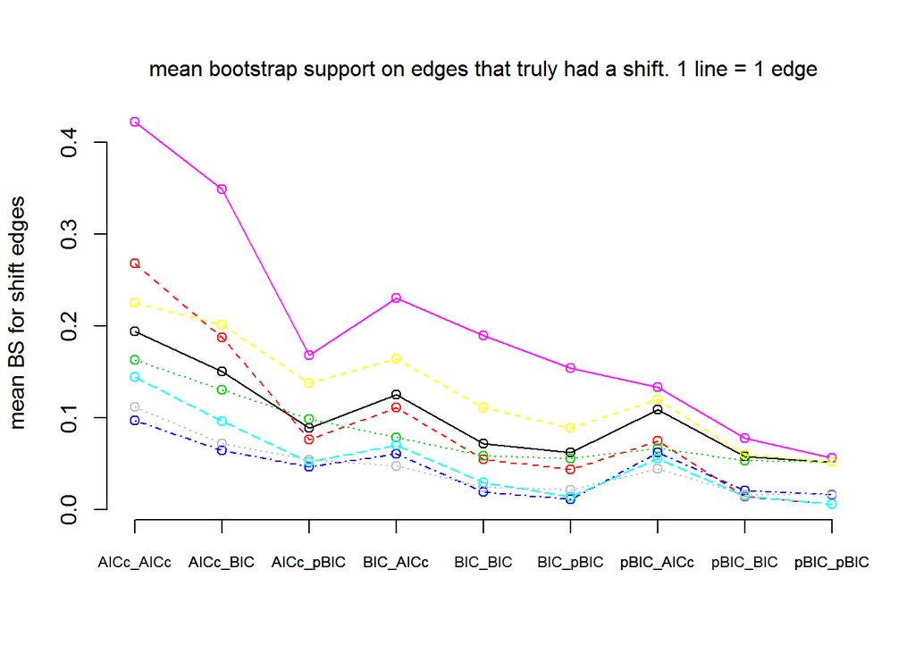

```r
matplot(means_sum, type = c("o"),pch=1,col = 1:8,ylab="mean BS for shift edges",axes=F)
axis(side=1,at=1:9,labels = plot_name,cex.axis=0.7)
axis(side=1,at=2,labels = plot_name[2],cex.axis=0.7)
axis(side=1,at=3,labels = plot_name[3],cex.axis=0.7)
axis(side=1,at=4,labels  = plot_name[4],cex.axis=0.7)
axis(side=1,at=7,labels = plot_name[7],cex.axis=0.7)
axis(side=1,at=9,labels = plot_name[9],cex.axis=0.7)
axis(side=2,ylim=c(0:0.6))
mtext("mean bootstrap support on edges that truly had a shift. 1 line = 1 edge",
      line=1,side=3,las=0)
```

#### Mean BS and other summaries, for non-shift edges

```r
meano_sum=matrix(data=NA,nrow=9,ncol=n_edges-length(shiftedge))
sdo_sum=matrix(data=NA,nrow=9,ncol=n_edges-length(shiftedge))
maxo_sum=matrix(data=NA,nrow=9,ncol=n_edges-length(shiftedge))
# will contain the mean, standard deviation, max bootstrap support
# of non-shift edges across 100 simulations.

# now filling in the values
for (i in 1:9){
  meano_sum[i,]=colMeans(vectorOfTables[[i]][,otheredge])
  sdo_sum[i,]=apply(vectorOfTables[[i]],2,sd)[otheredge]
  maxo_sum[i,]=apply(vectorOfTables[[i]],2,max)[otheredge]
}

round(meano_sum[,1:10],3) # Mean BS: row = procedure (like aic_aic), column = edge with no shift
```

```
##        [,1]  [,2]  [,3]  [,4]  [,5]  [,6]  [,7]  [,8]  [,9] [,10]
##  [1,] 0.014 0.006 0.041 0.024 0.055 0.031 0.004 0.003 0.041 0.035
##  [2,] 0.008 0.002 0.025 0.012 0.032 0.013 0.001 0.001 0.023 0.016
##  [3,] 0.006 0.001 0.008 0.009 0.010 0.005 0.000 0.000 0.008 0.008
##  [4,] 0.005 0.006 0.034 0.020 0.057 0.036 0.003 0.003 0.025 0.032
##  [5,] 0.002 0.001 0.013 0.003 0.009 0.009 0.001 0.001 0.006 0.006
##  [6,] 0.002 0.004 0.010 0.003 0.003 0.003 0.004 0.000 0.003 0.007
##  [7,] 0.006 0.005 0.024 0.019 0.059 0.042 0.003 0.002 0.027 0.036
##  [8,] 0.002 0.001 0.008 0.007 0.013 0.009 0.002 0.001 0.009 0.009
##  [9,] 0.003 0.001 0.005 0.002 0.003 0.017 0.001 0.004 0.002 0.006
```

```r
round(sdo_sum[,1:10],3) # SD BS: row = procedure (like aic_aic), column = edge with no shift
```

```
##        [,1]  [,2]  [,3]  [,4]  [,5]  [,6]  [,7]  [,8]  [,9] [,10]
##  [1,] 0.070 0.010 0.123 0.095 0.137 0.095 0.008 0.006 0.128 0.107
##  [2,] 0.047 0.006 0.109 0.078 0.116 0.056 0.002 0.004 0.087 0.067
##  [3,] 0.044 0.005 0.063 0.083 0.054 0.031 0.002 0.000 0.033 0.053
##  [4,] 0.008 0.009 0.091 0.016 0.030 0.020 0.006 0.005 0.018 0.018
##  [5,] 0.006 0.005 0.087 0.007 0.013 0.016 0.003 0.004 0.011 0.010
##  [6,] 0.011 0.034 0.072 0.015 0.010 0.015 0.034 0.002 0.020 0.051
##  [7,] 0.009 0.008 0.016 0.012 0.023 0.022 0.005 0.005 0.017 0.018
##  [8,] 0.006 0.006 0.012 0.013 0.018 0.014 0.006 0.004 0.015 0.013
##  [9,] 0.012 0.007 0.029 0.009 0.013 0.103 0.009 0.027 0.010 0.031
```

Now we can again visualize these BS means, one for each edge:

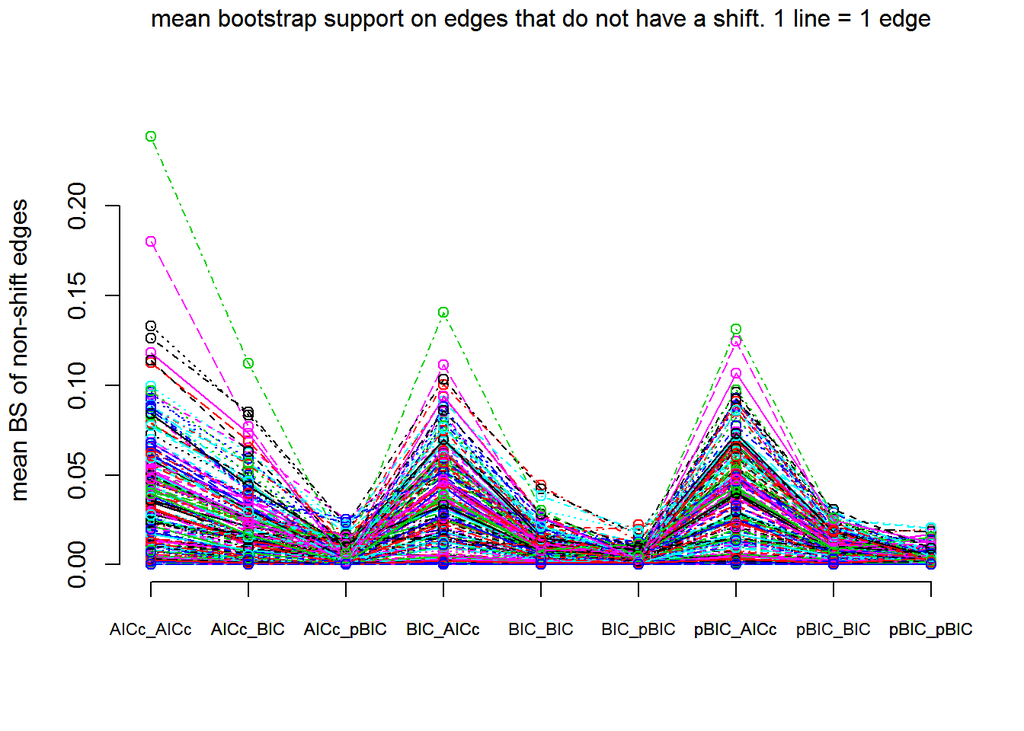

```r
#Plotting the means,sds
layout(matrix(1, 1))
matplot(meano_sum, type = c("o"),pch=1,ylab="mean BS of non-shift edges",axes=F)
axis(side=1,at=1:9,labels = plot_name,cex.axis=0.7)
axis(side=1,at=2,labels = plot_name[2],cex.axis=0.7)
axis(side=1,at=3,labels = plot_name[3],cex.axis=0.7)
axis(side=1,at=4,labels = plot_name[4],cex.axis=0.7)
axis(side=1,at=7,labels = plot_name[7],cex.axis=0.7)
axis(side=1,at=9,labels = plot_name[9],cex.axis=0.7)
axis(side=2,ylim=c(0:0.6))
mtext("mean bootstrap support on edges that do not have a shift. 1 line = 1 edge",
      line=3,side=3,las=0)
```

```r
which(meano_sum[1,]>.2) #  189th in "otheredge" = 197 in table with all edges.
```

```
## [1] 189
```

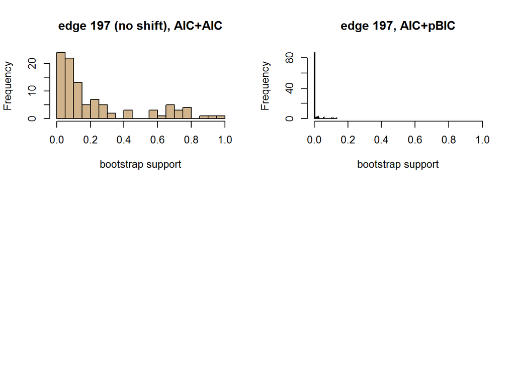

```r
layout(matrix(1:4, 2, 2, byrow=TRUE))
#hist(aic_aic[,otheredge[30]],breaks=20,xlab="bootstrap support",
 #    main="edge 31 (no shift), AIC+AIC",col="tan")# almost flat between 0 and 1
#hist(aic_pbic[,otheredge[30]],breaks=20,xlab="bootstrap support",
#     main="edge 31, AIC+pBIC ", col="green", xlim=0:1)# unimodal near 0
hist(aic_aic[,otheredge[189]],breaks=20,xlab="bootstrap support",
     main="edge 197 (no shift), AIC+AIC",col="tan")# almost flat between 0 and 1
hist(aic_pbic[,otheredge[189]],breaks=20,xlab="bootstrap support",
     main="edge 197, AIC+pBIC",col="green", xlim=0:1)# unimodal near 0
```

### Distribution of BS on shift edges to find a threshold for “high” versus “low” support

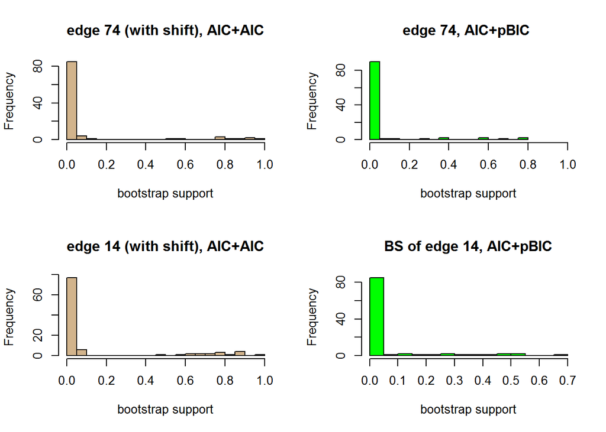

```r
layout(matrix(1:4, 2, 2, byrow=TRUE))
hist(aic_aic[,shiftedge[4]],breaks=20,xlab="bootstrap support",
     main="edge 74 (with shift), AIC+AIC",col="tan")
hist(aic_pbic[,shiftedge[4]],breaks=20,xlab="bootstrap support", xlim=0:1,
     main="edge 74, AIC+pBIC ", col="green")
hist(aic_aic[,shiftedge[5]],breaks=20,xlab="bootstrap support",
     main="edge 14 (with shift), AIC+AIC",col="tan")
hist(aic_pbic[,shiftedge[5]],breaks=20,xlab="bootstrap support",
     main="BS of edge 14, AIC+pBIC",col="green")
```

# Display of edge BS means and frequency of high support

Here we display results for each edge, summarized across all simulated data. Below, the plot on the left shows the mean bootstrap support for each edge, if it is 0.05 or higher. The plot on the right shows, for each edge, the proportion of replicates who had a BS of 40% of higher for that edge (this proportion is not shown if it is lower than 0.01).

These plots are shown for 2 procedures only: the most liberal AICc+AICc and our recommended procedure: AICc+pBIC.

```r
plotShiftSupport = function(k){
  layout(matrix(1:2, 1, 2))
  bs_high=colSums(vectorOfTables[[k]]>=0.4)
  pro_high=bs_high/100
  ind_high=which(pro_high>0.01)
  ind_means=which(all_means[k,]>=0.05)
  ins_ps=intersect(shiftedge,ind_high)
  ins_po=intersect(otheredge,ind_high)
  ins_ms=intersect(shiftedge,ind_means)
  ins_mo=intersect(otheredge,ind_means)
  list =c(1,2,4,7) # those methods have indices from ind_means that are not shift edges.
  plot(eModel$tree,show.tip.label = F,main=plot_name[k],sub=
"Blue: edges with a true shift.
Pink: edges with no shift.",font=8)
  edgelabels(round(all_means[k,ins_ms],2),ins_ms,col="blue",frame="none")
  if (k %in% list){
  edgelabels(round(all_means[k,ins_mo],2),ins_mo,col="pink",frame="none")
  }
  mtext(text ="Mean bootstrap support across simulations.
Not shown if < 0.05.",font=6,line=-1)
  plot(eModel$tree,show.tip.label = F,main=plot_name[k],sub=
"Red: edges with a true shift.
Green: edges with no shift.",font=8)
  edgelabels(round(pro_high[ins_ps],2),ins_ps,col="red",frame="none")
  edgelabels(round(pro_high[ins_po],2),ins_po,col="green",frame="none")
  mtext(text ="Proportion of replicates with BS >=0.4.
Not shown if <= 0.01.", line=-1)
}
plotShiftSupport(1)
```

[figure not shown]

```r
plotShiftSupport(3)
```

[figure not shown]

For the figures for all the 9 procedures, please see file `prop_plots.pdf`.

```r
pdf("prop_plots.pdf", width=8.5, height=11)
layout(matrix(1:2, 1, 2))
for (k in 1:9){ # kth row = kth procedure. k=1=the first row=aic_aic
  plotShiftSupport(k)
}
dev.off()
```

The results for the procedures not shown above are summarized below:

When pBIC was the first criterion, non-shift edges tended to have low support, but 6 true shifts had high BS in 2% of less of simulated data.

# Overall number of false and true positives

We now look at all edges with high support for each given replicate. We define a false positive as a non-shift edge that had the bootstrap support of 0.4 or higher. A true positive is a shift edge with the bootstrap support of 0.4 or higher. For each simulated data, we counted the number of false positives and the number of true positives, and then we calculated the mean and standard deviation of these false and true positives across 100 replicates.

```r
falist=matrix(data=NA,nrow=9,ncol=100) # number of non-shift edges with high BS: row=procedure, col=simulated data
trulist=matrix(data=NA,nrow=9,ncol=100) # number of shift edges  with high BS
for (k in 1:9){
  for (i in 1:100){
    falist[k,i]=sum(vectorOfTables[[k]][i,otheredge]>=0.4)
    trulist[k,i]=sum(vectorOfTables[[k]][i,shiftedge]>=0.4)
  }
}

# mean and sd of true and false-positive number for each procedure
mean_fal=rowMeans(falist)
sd_fal=apply(falist,1,sd)
mean_tru=rowMeans(trulist)
sd_tru=apply(trulist,1,sd)

summ_table=data.frame(meanFP=mean_fal, sdFP=sd_fal, meanTP=mean_tru, sdTP=sd_tru)
summ_table$crit1=c("AICc","AICc","AICc","BIC","BIC","BIC","pBIC","pBIC","pBIC")
summ_table$crit2=c("AICc","BIC","pBIC","AICc","BIC","pBIC","AICc","BIC","pBIC")
summ_table
```

```
##   meanFP      sdFP meanTP      sdTP crit1 crit2
## 1   5.23 2.3043876   1.84 1.1075498  AICc  AICc
## 2   3.43 2.4173406   1.53 1.0584437  AICc   BIC
## 3   0.73 0.6942040   0.79 0.7951240  AICc  pBIC
## 4   0.44 1.0571546   0.57 0.8318775   BIC  AICc
## 5   0.44 1.0571546   0.57 0.8318775   BIC   BIC
## 6   0.37 0.5972158   0.50 0.7035265   BIC  pBIC
## 7   0.07 0.2564324   0.23 0.4682872  pBIC  AICc
## 8   0.07 0.2564324   0.23 0.4682872  pBIC   BIC
## 9   0.18 0.4794778   0.23 0.4682872  pBIC  pBIC
```

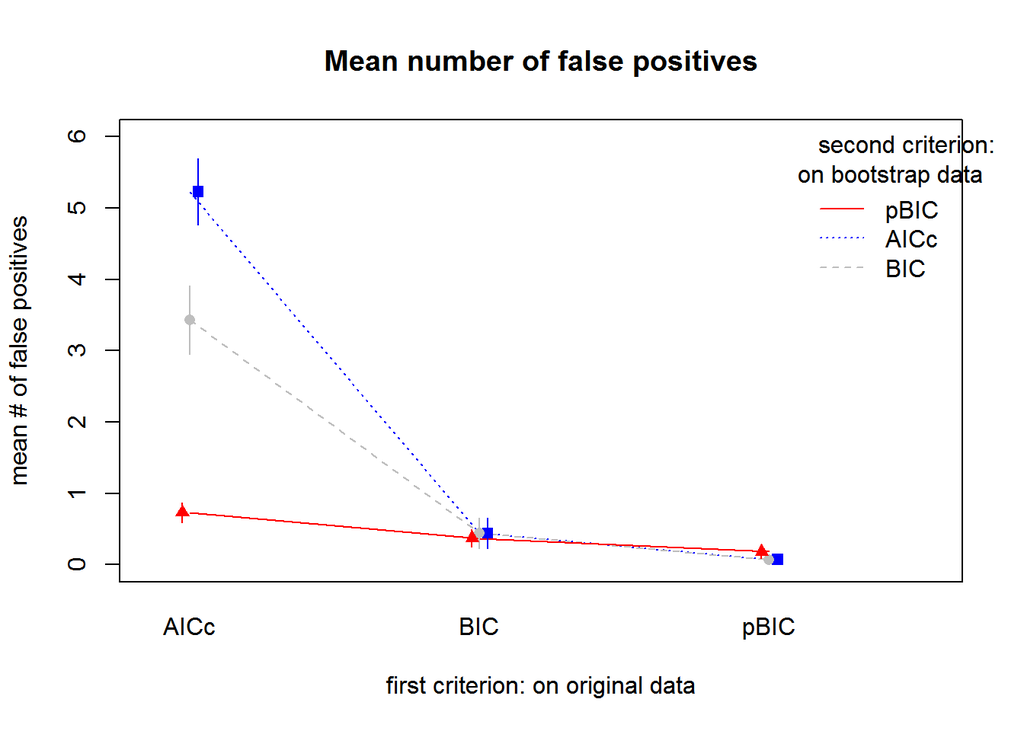

```r
xpos = c(1,2,3)
j=c(1,4,7) # procedures with aic as the second criterion
layout(matrix(1, 1))
interaction.plot(summ_table[,5],summ_table[,6],mean_fal,col=c("blue","gray","red"),
                 main="Mean number of false positives",
                 xlab="first criterion: on original data",
                 ylab="mean # of false positives",
                 trace.label="second criterion:\non bootstrap data",ylim=c(0,6))

# Add confidence interval on each point
for (m in critlist) {
  if (m=="AICc"){
    add=F
    meanplot=plotCI(xpos+0.03*(1-0.5*add),mean_fal[j],2*sd_fal[j]/10,
                    main ="", axes=F, add=T,pch=15,sfrac=0,col="blue")
  }
  if (m == "BIC") {
    add=T
    meanplot=plotCI(xpos+0.05*(1-add),mean_fal[j+1],2*sd_fal[j+1]/10,
                    main ="",ylab="",add=add,pch=16,sfrac=0,col="gray")
  }
  if (m=="pBIC"){ add=T
  meanplot=plotCI(xpos+0.05*(1-1.5*add),mean_fal[j+2],2*sd_fal[j+2]/10,
                  main ="",axes=F, add=T,pch=17,sfrac=0, col="red")
  }
}
```

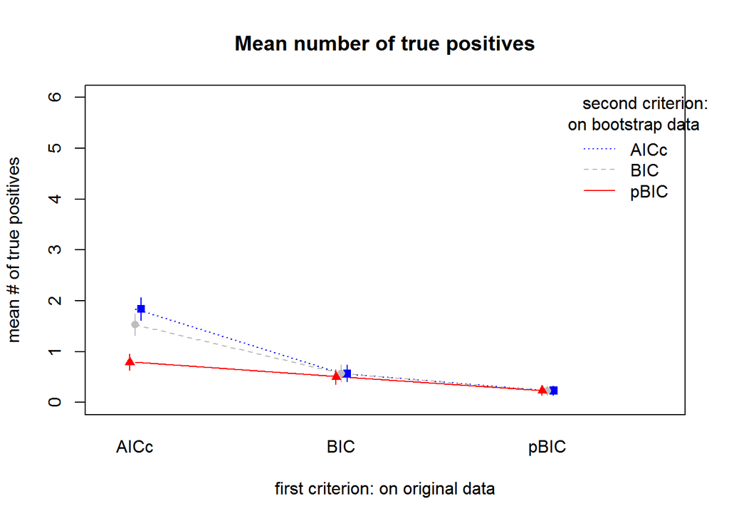

```r
interaction.plot(summ_table[,5],summ_table[,6],mean_tru,col=c("blue","gray","red"),
                 main="Mean number of true positives",
                 xlab="first criterion: on original data",
                 ylab="mean # of true positives",
                 trace.label="second criterion:\non bootstrap data",ylim=c(0,6))
# Add confidence interval on each point
for (m in critlist) {
  if (m=="AICc"){
    add=F
    meanplot=plotCI(xpos+0.03*(1-0.5*add),mean_tru[j],2*sd_tru[j]/10,
                    main ="", axes=F, add=T,pch=15,col="blue",sfrac=0)
  }
  if (m == "BIC") {
    add=T
    meanplot=plotCI(xpos+0.05*(1-add),mean_tru[j+1],2*sd_tru[j+1]/10,
                    main ="",ylab="",add=add,pch=16,col="gray",sfrac=0)
  }
  if (m=="pBIC"){ add=T
  meanplot=plotCI(xpos+0.05*(1-1.5*add),mean_tru[j+2],2*sd_tru[j+2]/10,
                  main ="",axes=F, add=T,pch=17,sfrac=0,col="red")
  }
}
```

When AICc is the first criterion, then the second criterion can change the mean number of false positives and true positives significantly: with AICc as the second criterion again, the mean number of false positive and of true positives is larger than with BIC or pBIC. When BIC or pBIC is the first criterion, the second criterion has little impact on the number of false/true positives. There are fewer true positives with pBIC than with BIC (as first criterion), for a similar number of false positives.

The distribution of false and true positives is unimodal in all cases. Only 2 procedures are shown below: the most liberal AICc+AICc and our recommended procedure AICc+pBIC:

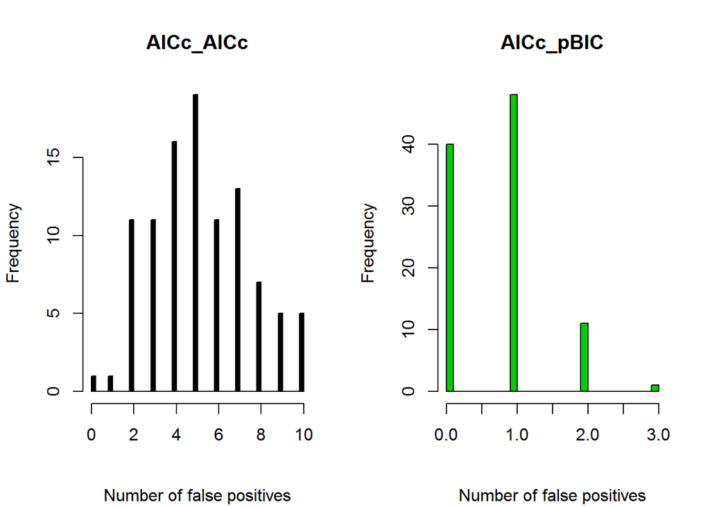

```r
layout(matrix(1:2, 1, 2))
# create histgram of false-positive BS for each procedure
hist(falist[1,],main=plot_name[1],breaks=40,col=1,sub="Number of false positives",xlab="")
hist(falist[3,],main=plot_name[3],breaks=40,col=3,sub="Number of false positives",xlab="")
```

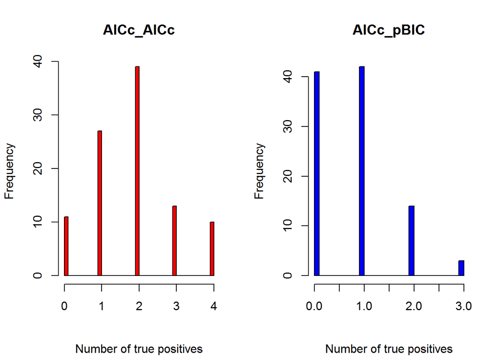

```r
# create histgram of true-positive BS for each procedure
hist(trulist[1,],main=plot_name[1],breaks=40,col=2,sub="Number of true positives",xlab="")
hist(trulist[3,],main=plot_name[3],breaks=40,col=4,sub="Number of true positives",xlab="")
```

Most of the time, AICc + AICc lead to 2-9 false positives and 1-4 true positives, and AICc + pBIC lead to 0-2 false positives and 0-2 true positives.

See files `falist_plots.pdf` and `trulist_plots.pdf` for the false and true positive histograms with other procedures.

```r
# create histgram of false-positive BS for each procedure
pdf("falist_plots.pdf", height=10.5, width=8.5)
par(mfrow=c(2,2))
for (k in 1:9){
  hist(falist[k,],main=plot_name[k],breaks=40,col=k,sub="Number of false positives",xlab="")
}
dev.off()

# create histgram of true-positive BS for each procedure
pdf("trulist_plots.pdf", height=10.5, width=8.5)
par(mfrow=c(2,2))
for (k in 1:9){
  hist(trulist[k,],main=plot_name[k],breaks=40,col=k,sub="Number of true positives",xlab="")
}
dev.off()
```